# Machine Learning Project: UAP/UFO Sightings from National UFO Research Center (NUFORC)

# What are the highest frequencies and probabilities of UFO sighting given year, city, and country (not in the US)?

```python
# copy ufo_reset_df to ufo_cities
ufo_cities = ufo_reset_df.copy()

# subset the ufo_cities with columns needed
ufo_cities = ufo_cities[["city","state","country","year","freq","percent_prob"]]
# filter out USA from ufo_cities dataframe
ufo_cities = ufo_cities.loc[ufo_cities["country"] != "USA"]
# get the top prob values
high_prob =ufo_cities.groupby(["year","city","country","freq","percent_prob"]).size()
# sort in descending order
high_prob = high_prob.sort_values(ascending=False)
# get the top shape values
high_prob = high_prob.head(15)
# reset the index to count to get a dataframe
high_prob = high_prob.reset_index(name="count")
# add 1 to the index so list starts at 1
high_prob.index = high_prob.index + 1

print("Top Non-USA Cities with Highest Frequencies & Probabilities of UFO Sightings based on year, city, country")
print(high_prob)
```

```
Top Non-USA Cities with Highest Frequencies & Probabilities of UFO Sightings based on year, city, country
    year       city country  freq  percent_prob  count
1   2022   Gatineau  Canada  39.0        0.0059     39
2   2003    Terrace  Canada  25.0        0.0038     25
3   2003    Houston  Canada  23.0        0.0035     23
4   2003  Vancouver  Canada  21.0        0.0032     21
5   2004    Toronto  Canada  20.0        0.0030     20
6   2005    Toronto  Canada  17.0        0.0026     17
7   2013    Toronto  Canada  15.0        0.0023     15
8   2014    Toronto  Canada  15.0        0.0023     15
9   2001  Vancouver  Canada  14.0        0.0021     14
10  2004   Edmonton  Canada  14.0        0.0021     14
11  2007    Toronto  Canada  14.0        0.0021     14
12  2020    Toronto  Canada  13.0        0.0020     13
13  2013     Ottawa  Canada  13.0        0.0020     13
14  2015   Edmonton  Canada  13.0        0.0020     13
15  2015    Toronto  Canada  13.0        0.0020     13
```

# Create a bar chart for top frequencies and probabilities in a year, city and country not in the USA

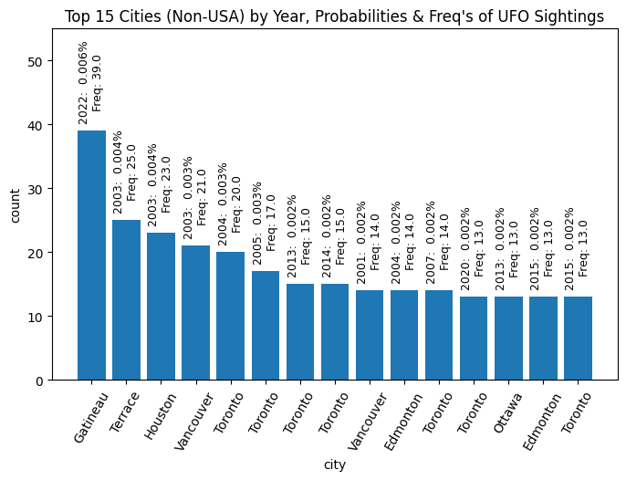

```python
# make fig and ax objects and set figure size
fig, ax = plt.subplots(figsize=(8,5))

# get x and y values from high_prob dataframe
x = high_prob["city"]
y = high_prob["count"]

# make a bar chart with the x and y values; for x values use np.arange() to create an array of values
bar_container = ax.bar(np.arange(15), y)

# convert bar_container object into a BarContainer object to use bar_container.patches
bar_container = BarContainer(bar_container)

# set the labels and title
ax.set(xlabel="city", ylabel="count", title="Top 15 Cities (Non-USA) by Year, Probabilities & Freq's of UFO Sightings")

# subset high_prob["year","percent_prob","count"] into a list
yr_count = high_prob[["year","percent_prob","count"]]

# make an empty list to store the labels
label_list = list()

# iterate over the rows of the yr_count dataframe
for index, row in yr_count.iterrows():
    # assign the values of the year, percent_prob, and count columns from each row
    year = int(row["year"])
    year = str(year)
    freq = str(row["count"])
    per_prob = str(round(row["percent_prob"], 3))
    # combine the year and count values into a single string
    label = year + ":  " + per_prob + "%\nFreq: " + freq
    # append this string to the label_list
    label_list.append(label)

# format the bar_label object with bar_container.patches and label_list, slicing it to 15 items
ax.bar_label(bar_container.patches, labels=label_list[:15], fontsize=9, rotation=90, padding=6)

# set the xticks and xticklabels
# use np.arange() to create even-spaced xtick marks
ax.set_xticks(np.arange(15))
# use the cities in high_prob["city"] as the xticklabels
ax.set_xticklabels(high_prob["city"], rotation=60)
# set the y-axis limit
plt.ylim(0, 55)
plt.savefig("plots/top_nonusa_cities_prob_barchart.png")
plt.show()
```

# Create US map for the actual and predicted probabilities

```python
#ufo_cities.loc[ufo_cities["city"] == "San Angelo"].tail(60)
```

```python
# US Cities Map
import folium

# copy preds_cities to ufo_cities
ufo_cities = preds_cities.copy()

# filter out other countries but the USA from ufo_int
ufo_cities = ufo_cities.loc[ufo_cities["country"] == "USA"]
# subset the ufo_cities with columns needed
ufo_cities = ufo_cities[["year","city","state","country","city_latitude","city_longitude","percent_prob","rf_pred_percent_prob"]]

# reduce observations by limiting the years > 2020
ufo_cities = ufo_cities.loc[ufo_cities["year"] > 2020]

# drop missing values
ufo_cities = ufo_cities.dropna()

# make a cities_list to display in map
cities_list = ["Haiku","Honolulu","Los Angeles","San Francisco","Reno","Las Vegas","Sparks","Eugene",
               "Salem","Portland,""Seattle","Lakewood","Auburn","Tucson","Boulder","Denver",
               "Colorado Springs","Provo","Phoenix","Roswell","Albuquerque","Billings","Bismarck",
               "Fargo","Pierre","Bozeman","Missoula","Casper","Douglas",
               "Des Moines","Cedar Rapids","Sioux City","Cheyenne","Chicago","Tinley Park","Omaha",
               "Sioux Falls","Detroit","Louisville","Columbus","Cleveland","Baltimore","Pittsburgh","St. Paul",
               "Fairbanks","Anchorage","Grand Rapids","Pittsburgh","Philadelphia","Boise",
               "Salt Lake City","Austin","Houston","San Angelo","Oklahoma","Wichita","Nashville",
               "Memphis","New York","Brooklyn","Boston","Providence","Hartford","Myrtle Beach",
               "Washington","Richmond","Charleston","Raleigh","Mobile","Atlanta","New Orleans",
               "Augusta","Jacksonville","Miami","Tampa","Orlando"]
# Removed: Newport
# filter the dataframe by city is in cities_list
ufo_cities = ufo_cities.loc[ufo_cities["city"].isin(cities_list)]

# create a folium map object with Wichita's as the location view
map = folium.Map(location=[38, -97], zoom_start=4)

# add a marker for each city with a popup showing its name and percent probabilty
for i, row in ufo_cities.iterrows():
    folium.Marker(
        location=[row["city_latitude"], row["city_longitude"]],
        popup=f"{row['city']}, {row['state']} ({row['year']})<br>actual_%prob={row['percent_prob']}%<br>pred_%prob={round(row['rf_pred_percent_prob'],4)}%",
        tooltip=f"{row['city']} {row['year']}<br>{row['percent_prob']}%"
    ).add_to(map)

# Save and display the map
map.save("maps/us_cities_map.html")
map
```

Make this Notebook Trusted to load map: File -> Trust Notebook

[interactive chart not shown]

```python
# Find latitude and longitude values for select cities
import geocoder
from geopy.geocoders import GoogleV3

# assign_lat_lon() takes a dataframe, a city string, and a country string as arguments
#   and assigns geocode values to the city_latitude and city_longitude columns
def assign_lat_lon(df, city, country):
    # use the geocoder library to get the latitude and longitude values for the city
    result = geocoder.osm(f"{city}, {country}")

    if result.ok:
        # make a boolean mask that is True for rows where city column == city argument and country column == country argument
        mask = (df["city"] == city) & (df["country"] == country)
        # assign the values to the dataframe using the loc method and the mask as the index
        df.loc[mask, "city_latitude"] = result.lat
        df.loc[mask, "city_longitude"] = result.lng
    else:
        # get latitude and longitude using GoogleV3's geolocater
        geolocator = GoogleV3(api_key="AIzaSyD4SjwqDaCWcQBbBMgnY755RaXbs0vgm3w")
        # Use the geocode method to get the coordinates of an address
        result2 = geolocator.geocode(f"{city}, {country}")
        if result2:
            # make a boolean mask that is True for rows where city column == city argument and country column == country argument
            mask = (df["city"] == city) & (df["country"] == country)
            # assign the values to the dataframe using the loc method and the mask as the index
            df.loc[mask, "city_latitude"] = result2.latitude
            df.loc[mask, "city_longitude"] = result2.longitude
    return df
```

```python
# copy ufo_reset_df to ufo_cities
ufo_cities = ufo_reset_df.copy()
# subset the ufo_cities with columns needed
ufo_cities = ufo_cities[["city","state","country","city_latitude","city_longitude","date_time","year","freq","prob","percent_prob"]]
```

```python
#ufo_reset_df.loc[ufo_reset_df["state"] == "NV"].tail(60)
#ufo_cities.loc[ufo_cities["city"] == "Sparks"].tail(60)
```

```python
# fill in the latitude and longitude values of rows missing city_latitude and ciy_longitude values
missing_df = ufo_cities.isna()
# use the any() method to check if there are any missing values in the city_latitude and city_longitude columns
missing_lat_lon = missing_df["city_latitude"].any() or missing_df["city_longitude"].any()

# if there are missing values, call assign_lat_lon() with city and country arguments;
#   cities from the Americas and Europe are hard-coded in
if missing_lat_lon:
    ufo_cities = assign_lat_lon(ufo_cities, "Gatineau","Canada")
    ufo_cities = assign_lat_lon(ufo_cities, "Ontario","Canada")
    ufo_cities = assign_lat_lon(ufo_cities, "Montreal","Canada")
    ufo_cities = assign_lat_lon(ufo_cities, "Coquitlam","Canada")
    ufo_cities = assign_lat_lon(ufo_cities, "Lingan","Canada")
    ufo_cities = assign_lat_lon(ufo_cities, "Sudbury","Canada")
    ufo_cities = assign_lat_lon(ufo_cities, "San Juan","Puerto Rico")
    ufo_cities = assign_lat_lon(ufo_cities, "Sandy Point","St. Kitts")
    ufo_cities = assign_lat_lon(ufo_cities, "San Sebastián","Puerto Rico")
    ufo_cities = assign_lat_lon(ufo_cities, "Cayo Guillermo","Cuba")
    ufo_cities = assign_lat_lon(ufo_cities, "Havana","Cuba")
    ufo_cities = assign_lat_lon(ufo_cities, "San Jose","Costa Rica")
    ufo_cities = assign_lat_lon(ufo_cities, "Farallon","Panama")
    ufo_cities = assign_lat_lon(ufo_cities, "Panama","Panama")
    ufo_cities = assign_lat_lon(ufo_cities, "Oaxaca City","Mexico")
    ufo_cities = assign_lat_lon(ufo_cities, "Mexico City","Mexico")
    ufo_cities = assign_lat_lon(ufo_cities, "Puerto Penasco","Mexico")
    ufo_cities = assign_lat_lon(ufo_cities, "Cancun","Mexico")
    ufo_cities = assign_lat_lon(ufo_cities, "Tijuana","Mexico")
    ufo_cities = assign_lat_lon(ufo_cities, "Puerto Vallarta","Mexico")
    ufo_cities = assign_lat_lon(ufo_cities, "Guatemala City","Guatemala")
    ufo_cities = assign_lat_lon(ufo_cities, "Quito","Ecuador")
    ufo_cities = assign_lat_lon(ufo_cities, "Managua","Nicaragua")
    ufo_cities = assign_lat_lon(ufo_cities, "Lima","Peru")
    ufo_cities = assign_lat_lon(ufo_cities, "Bogotá","Colombia")
    ufo_cities = assign_lat_lon(ufo_cities, "Medellin","Colombia")
    ufo_cities = assign_lat_lon(ufo_cities, "Caracas","Venezuela")
    ufo_cities = assign_lat_lon(ufo_cities, "Buenos Aires","Argentina")
    ufo_cities = assign_lat_lon(ufo_cities, "Rio de Janeiro","Brazil")
    ufo_cities = assign_lat_lon(ufo_cities, "SÃO PAULO","Brazil")
    ufo_cities = assign_lat_lon(ufo_cities, "Juazeiro Do Norte","Brazil")
    ufo_cities = assign_lat_lon(ufo_cities, "Achumani","Bolivia")
    ufo_cities = assign_lat_lon(ufo_cities, "Santiago","Chile")
    ufo_cities = assign_lat_lon(ufo_cities, "Ceuse","France")
    ufo_cities = assign_lat_lon(ufo_cities, "Paris","France")
    ufo_cities = assign_lat_lon(ufo_cities, "Rome","Italy")
    ufo_cities = assign_lat_lon(ufo_cities, "Florence","Italy")
    ufo_cities = assign_lat_lon(ufo_cities, "Barcelona","Spain")
    ufo_cities = assign_lat_lon(ufo_cities, "Málaga","Spain")
    ufo_cities = assign_lat_lon(ufo_cities, "Lisbon","Portugal")
    ufo_cities = assign_lat_lon(ufo_cities, "Venice","Italy")
    ufo_cities = assign_lat_lon(ufo_cities, "Berlin","Germany")
    ufo_cities = assign_lat_lon(ufo_cities, "Munich","Germany")
    ufo_cities = assign_lat_lon(ufo_cities, "Warsaw","Poland")
    ufo_cities = assign_lat_lon(ufo_cities, "Krakow","Poland")
    ufo_cities = assign_lat_lon(ufo_cities, "Zurich","Switzerland")
    ufo_cities = assign_lat_lon(ufo_cities, "Prague","Czech Republic")
    ufo_cities = assign_lat_lon(ufo_cities, "Zagreb","Croatia")
    ufo_cities = assign_lat_lon(ufo_cities, "Bucharest","Romania")
    ufo_cities = assign_lat_lon(ufo_cities, "Helsinki","Finland")
    ufo_cities = assign_lat_lon(ufo_cities, "Oslo","Norway")
    ufo_cities = assign_lat_lon(ufo_cities, "Stockholm","Sweden")
    ufo_cities = assign_lat_lon(ufo_cities, "Næstved","Denmark")
    ufo_cities = assign_lat_lon(ufo_cities, "Reykjavík","Iceland")
    ufo_cities = assign_lat_lon(ufo_cities, "Amsterdam","Netherlands")
    ufo_cities = assign_lat_lon(ufo_cities, "The Hague","Netherlands")
    ufo_cities = assign_lat_lon(ufo_cities, "Kiev","Ukraine")
    ufo_cities = assign_lat_lon(ufo_cities, "Kyiv","Ukraine")
    ufo_cities = assign_lat_lon(ufo_cities, "Sydney","Australia")
    ufo_cities = assign_lat_lon(ufo_cities, "Brisbane","Australia")
    ufo_cities = assign_lat_lon(ufo_cities, "Melbourne","Australia")
    ufo_cities = assign_lat_lon(ufo_cities, "London","United Kingdom")
    ufo_cities = assign_lat_lon(ufo_cities, "Essex","United Kingdom")
    ufo_cities = assign_lat_lon(ufo_cities, "Manchester","United Kingdom")
    ufo_cities = assign_lat_lon(ufo_cities, "Liverpool","United Kingdom")
    ufo_cities = assign_lat_lon(ufo_cities, "Dublin","United Kingdom")
    ufo_cities = assign_lat_lon(ufo_cities, "Alloa","United Kingdom")
    ufo_cities = assign_lat_lon(ufo_cities, "Athens","Greece")
    ufo_cities = assign_lat_lon(ufo_cities, "Kolymbia Beach","Greece")
    ufo_cities = assign_lat_lon(ufo_cities, "Istanbul","Turkey")
```

```python
# if there are missing values, call assign_lat_lon() with city and country arguments;
#   cities from Asia, Africa, and Middle East
if missing_lat_lon:
    ufo_cities = assign_lat_lon(ufo_cities, "Meerut","India")
    ufo_cities = assign_lat_lon(ufo_cities, "Delhi","India")
    ufo_cities = assign_lat_lon(ufo_cities, "Port Blair","India")
    ufo_cities = assign_lat_lon(ufo_cities, "Bangalore","India")
    ufo_cities = assign_lat_lon(ufo_cities, "Senji","India")
    ufo_cities = assign_lat_lon(ufo_cities, "Lahore","Pakistan")
    ufo_cities = assign_lat_lon(ufo_cities, "Kabul","Afghanistan")
    ufo_cities = assign_lat_lon(ufo_cities, "Tokyo","Japan")
    ufo_cities = assign_lat_lon(ufo_cities, "Ueda","Japan")
    ufo_cities = assign_lat_lon(ufo_cities, "Yokohama","Japan")
    ufo_cities = assign_lat_lon(ufo_cities, "SANYA","China")
    ufo_cities = assign_lat_lon(ufo_cities, "Changchun","China")
    ufo_cities = assign_lat_lon(ufo_cities, "Shanghai","China")
    ufo_cities = assign_lat_lon(ufo_cities, "Beijing","China")
    ufo_cities = assign_lat_lon(ufo_cities, "Hong Kong","China")
    ufo_cities = assign_lat_lon(ufo_cities, "Nantou","Taiwan")
    ufo_cities = assign_lat_lon(ufo_cities, "Taipei","Taiwan")
    ufo_cities = assign_lat_lon(ufo_cities, "Singapore","Singapore")
    ufo_cities = assign_lat_lon(ufo_cities, "Kuala Lumpur","Malaysia")
    ufo_cities = assign_lat_lon(ufo_cities, "Koh Samui","Thailand")
    ufo_cities = assign_lat_lon(ufo_cities, "Bangkok","Thailand")
    ufo_cities = assign_lat_lon(ufo_cities, "Ho Chi Minh City","Vietnam")
    ufo_cities = assign_lat_lon(ufo_cities, "Seoul","South Korea")
    ufo_cities = assign_lat_lon(ufo_cities, "Manila","Philippines")
    ufo_cities = assign_lat_lon(ufo_cities, "Angeles City","Philippines")
    ufo_cities = assign_lat_lon(ufo_cities, "Cebu","Philippines")
    ufo_cities = assign_lat_lon(ufo_cities, "Jakarta","Indonesia")
    ufo_cities = assign_lat_lon(ufo_cities, "Auckland","New Zealand")
    ufo_cities = assign_lat_lon(ufo_cities, "Wellington","New Zealand")
    ufo_cities = assign_lat_lon(ufo_cities, "Smolensk","Russia")
    ufo_cities = assign_lat_lon(ufo_cities, "Khabarovsk","Russia")
    ufo_cities = assign_lat_lon(ufo_cities, "Tikhoretsk","Russia")
    ufo_cities = assign_lat_lon(ufo_cities, "Moscow","Russia")
    ufo_cities = assign_lat_lon(ufo_cities, "St. Petersburg","Russia")
    ufo_cities = assign_lat_lon(ufo_cities, "Nairobi","Kenya")
    ufo_cities = assign_lat_lon(ufo_cities, "Cairo","Egypt")
    ufo_cities = assign_lat_lon(ufo_cities, "Johannesburg","South Africa")
    ufo_cities = assign_lat_lon(ufo_cities, "Cape Town","South Africa")
    ufo_cities = assign_lat_lon(ufo_cities, "Durban","South Africa")
    ufo_cities = assign_lat_lon(ufo_cities, "Harare","Zimbabwe")
    ufo_cities = assign_lat_lon(ufo_cities, "Casablanca","Morocco")
    ufo_cities = assign_lat_lon(ufo_cities, "Addis Ababa","Ethiopia")
    ufo_cities = assign_lat_lon(ufo_cities, "Lagos","Nigeria")
    ufo_cities = assign_lat_lon(ufo_cities, "Algiers","Algeria")
    ufo_cities = assign_lat_lon(ufo_cities, "Tripoli","Libya")
    ufo_cities = assign_lat_lon(ufo_cities, "Tehran","Iran")
    ufo_cities = assign_lat_lon(ufo_cities, "Baghdad","Iraq")
    ufo_cities = assign_lat_lon(ufo_cities, "Haifa","Israel")
    ufo_cities = assign_lat_lon(ufo_cities, "Jerusalem","Israel")
    ufo_cities = assign_lat_lon(ufo_cities, "Rekhasim","Israel")
    ufo_cities = assign_lat_lon(ufo_cities, "Tel-Aviv","Israel")
    ufo_cities = assign_lat_lon(ufo_cities, "Mecca","Saudi Arabia")
    ufo_cities = assign_lat_lon(ufo_cities, "Wadi Dhahal","Syria")
    ufo_cities = assign_lat_lon(ufo_cities, "Amman","Jordan")
    ufo_cities = assign_lat_lon(ufo_cities, "Muscat","Oman")
    ufo_cities = assign_lat_lon(ufo_cities, "Dubai","UAE")
```

```python
#ufo_reset_df.loc[ufo_reset_df["country"] == "India"].tail(60)
```

# World Map of Actual vs Predicted Probabilities of UFO Sightings

```python
# International Cities Map

# get the top prob values
#high_prob = preds_cities.groupby(["year","city","state","country","city_latitude","city_longitude","percent_prob","rf_pred_percent_prob"]).size()
# sort in descending order
#high_prob = high_prob.sort_values(ascending=False)

# copy preds_cities to ufo_cities
ufo_cities = preds_cities.copy()

# filter out the USA from ufo_cities
ufo_cities = ufo_cities.loc[ufo_cities["country"] != "USA"]
# subset the ufo_cities with columns needed
ufo_cities = ufo_cities[["year","city","state","country","city_latitude","city_longitude","percent_prob","rf_pred_percent_prob"]]

# reduce observations by limiting the years > 2020
ufo_cities = ufo_cities.loc[ufo_cities["year"] > 2020]

# drop missing values
ufo_cities = ufo_cities.dropna()

# make a cities_list to display in map
cities_list = ["Gatineau","Ontario","Ottawa","Toronto","Montreal","Coquitlam","Essex","Edmonton",
               "Calgary","Thamesford","New Westminster","Kingston","Ajax","Dartmouth","Sherwood Park",
               "Brandon","Orangeville","Nanaimo","Riverview","Sudbury","Vancouver",
               "Oaxaca City","Mexico City","San Jose","San Juan","Guayama","Sandy Point",
               "San Sebastián","Panama","Farallon","Cayo Guillermo","Havana","Bogotá","Medellin",
               "Puerto Vallarta","Santiago","Achumani","Puerto Penasco","Cancun","Tijuana",
               "Guatemala City","Quito","Managua","Lima","Buenos Aires","Rio de Janeiro","Barcelona",
               "Ceuse","Paris","Florence","Rome","Venice","Prague","The Hague","Bucharest",
               "Helsinki","Oslo","Lisbon","Málaga""Caracas","Munich","Berlin","Warsaw","Zurich",
               "Stockholm","Næstved","Reykjavík","Amsterdam","Kiev","Kyiv","Sydney","Melbourne",
               "Brisbane","London","Manchester","Liverpool","Dublin","Alloa","Athens","Port Blair",
               "Kolymbia Beach","Istanbul","Meerut","Delhi","Senji","Bangalore","Kabul","Lahore",
               "Tokyo","Ueda","Yokohama","SANYA","Changchun","Shanghai","Beijing","Hong Kong",
               "Singapore","Taipei","Nantou","Kuala Lumpur","Ho Chi Minh City","Seoul","Bangkok","Koh Samui",
               "Manila","Angeles City","Cebu","Tikhoretsk","Jakarta","Smolensk","Khabarovsk",
               "Moscow","St. Petersburg","Nairobi","Cairo","Johannesburg","Harare","Wellington",
               "Auckland","Cape Town","Durban","Casablanca","Addis Ababa","Lagos","Algiers",
               "Tehran","Baghdad","Haifa","Jerusalem","Tel-Aviv","Mecca","Wadi Dhahal","Amman",
               "Muscat","Dubai","Tripoli"]

# filter the dataframe by city is in cities_list
ufo_cities = ufo_cities.loc[ufo_cities["city"].isin(cities_list)]

# create a folium map object (location Juba, Sudan)
map = folium.Map(location=[5, 31], zoom_start=2)

# add a marker for each city with a popup showing its name and percent probabilty
for i, row in ufo_cities.iterrows():
    folium.Marker(
        location=[row["city_latitude"], row["city_longitude"]],
        popup=f"{row['city']}, {row['country']} ({row['year']})<br>actual_%prob={row['percent_prob']}%<br>pred_%prob={round(row['rf_pred_percent_prob'],4)}%",
        tooltip=f"{row['city']} {row['year']}<br>{row['percent_prob']}%"
    ).add_to(map)

# Save and display the map
map.save("maps/world_cities_map.html")
map
```

Make this Notebook Trusted to load map: File -> Trust Notebook

[interactive chart not shown]

# Model Analysis:

**Metrics:**

[output not shown]

**Apparent Trends:**

```
- The probability of a UAP sighting is pretty rare: certain cities have higher probabilities than others
- Seasonal trends: Summer months increase chances for a UAP sighting
- Weekly trends
- Daily trends
```

# Supplemental Questions Analysis: rough draft

**General Observations:**

- The US is the leading country with the most UAP sightings, with Canada and the United Kingdom as the countries having the next highest sightings. Being that the NUFORC is an American organization, the NUFORC naturally collects more US reports than any other countries. This collection bias is probably due in part to people from other countries not being aware of the NUFORC's existence. At this time, the NUFORC appears to accept English-only reports. This fact excludes the non-English-speaking populations of the world.

**Apparent Trends:**

### Add more:

-Problems:  
-hoax filter relying on judgment about sincerity of reports, but filter doesn't appear to affect the ranking of the data when it comes to grouping them by count (e.g. highest counts by city, highest counts by year)  
-collection bias